# Untitled

2025-04-05

## Fundamentos de Estadística para Analítica de datos

Integrantes

- Jimmy José Díaz Leyton
- Jessica Hasbleidy Pinilla Segovia
- Yenny Marisol Sánchez Sánchez

El uso de vehículos eléctricos ha experimentado un crecimiento significativo en los últimos años debido al interés en reducir la dependencia de los combustibles fósiles. Por ello, se ha tomado un conjunto de datos de vehículos eléctricos registrados en el estado de Washington con el propósito de examinar distintos aspectos relacionados con su comercialización y desempeño.

Se analizarán variables como el tipo de vehículo eléctrico (BEV - totalmente eléctrico y PHEV - híbrido enchufable), el precio base (MSRP) y el alcance eléctrico (Electric Range), con el fin de identificar patrones y diferencias entre estos modelos.

### **Variables cualitativas:**

1. **City** (Ciudad) - **Nominal**
2. **State** (Estado) - **Nominal**: “Washington”.
3. **Make** (Marca) - **Nominal**: Diferentes marcas de vehículos, como Tesla, Nissan, etc.
4. **Model** (Modelo) - **Nominal**: Diferentes modelos de vehículos.
5. **Electric Vehicle Type** (Tipo de vehículo eléctrico) - **Nominal**: Puede ser BEV (Battery Electric Vehicle) o PHEV (Plug-in Hybrid Electric Vehicle).
6. **Clean Alternative Fuel Vehicle (CAFV) Eligibility** (Preferencia para vehículo de combustible alternativo limpio) - **Nominal**
7. **Vehicle Location** (Ubicación del vehículo) - **Nominal**
8. **Electric Utility** (Utilidad eléctrica) - **Nominal**: Es el nombre de la empresa de servicios eléctricos que abastece el área.
9. **Legislative District** (Distrito legislativo) - **Nominal**: Representa los diferentes distritos legislativos en el estado de Washington.

### **Variables cuantitativas:**

1. **Postal Code** (Código Postal) - **Discreta**: Es un número que representa un código de área específico, pero es una variable discreta porque los códigos postales están en un conjunto limitado de valores.
2. **Model Year** (Año del modelo) - **Discreta**: Es un número entero que indica el año en que se fabricó el vehículo. Aunque es numérica, es discreta porque los valores son enteros y finitos.
3. **Electric Range** (Alcance eléctrico) - **Continua**: Es la distancia que puede recorrer un vehículo con una sola carga. Como puede tomar cualquier valor real dentro de un rango, es una variable continua.
4. **Base MSRP** (Precio base MSRP) - **Continua**: Es el precio base del vehículo, que puede tomar cualquier valor dentro de un rango, lo que lo convierte en una variable continua.
5. **2020 Census Tract** (Tracto censal de 2020) - **Nominal o discreta**: Aunque parece ser un identificador geográfico, en algunos casos puede ser tratado como una variable nominal (es un código de área), pero dependiendo del análisis, puede también considerarse discreta si se le usa para representar zonas geográficas.

### **Pregunta global:**

**¿Cuál es la relación entre el tipo de vehículo eléctrico (BEV vs PHEV), el precio base (MSRP) y el alcance eléctrico (Electric Range) de los vehículos registrados en el Estado de Washington?**

Esta pregunta abarca una perspectiva amplia que examina las diferencias entre los tipos de vehículos eléctricos (BEV y PHEV) en relación con dos variables cuantitativas clave: el precio y el alcance eléctrico. Esto te permitirá ver si existen patrones o diferencias significativas entre estos dos tipos de vehículos en cuanto a su precio y rendimiento.

### **Preguntas adicionales para apoyar la respuesta:**

   Esta pregunta te permitiría explorar si hay diferencias en la elegibilidad para incentivos o beneficios dependiendo del tipo de vehículo (BEV o PHEV) y cómo esto se relaciona con la ciudad o región en la que están registrados los vehículos.
4. **¿Qué relación existe entre el tipo de vehículo (BEV o PHEV) y la utilidad eléctrica que abastece la región en la que está registrado el vehículo?**  
   Esta pregunta busca explorar si existe alguna correlación entre el tipo de vehículo eléctrico y el proveedor de electricidad que tiene la región, lo que podría influir en la accesibilidad y la infraestructura de carga disponible.

### Cargar librerías necesarias

```r
library(tidyverse)
library(dplyr)
# Instalar TinyTeX
#install.packages("tinytex")
#tinytex::install_tinytex()
```

### Cargar datos (ajusta el nombre del archivo)

```r
datos<- read.csv("C:/Users/OptiPlex/OneDrive/Documentos/Universidad_Central/Opcion Estadistica/Proyecto/Electric_Vehicle_Population_Data.csv")
```

### Ver las primeras filas

```r
head(datos)
```

```
##   VIN..1.10.   County    City State Postal.Code Model.Year    Make      Model
## 1 5YJ3E1EBXK     King Seattle    WA       98178       2019   TESLA    MODEL 3
## 2 5YJYGDEE3L   Kitsap Poulsbo    WA       98370       2020   TESLA    MODEL Y
## 3 KM8KRDAF5P   Kitsap  Olalla    WA       98359       2023 HYUNDAI    IONIQ 5
## 4 5UXTA6C0XM   Kitsap Seabeck    WA       98380       2021     BMW         X5
## 5 JTMAB3FV7P Thurston Rainier    WA       98576       2023  TOYOTA RAV4 PRIME
## 6 5YJSA1DN0C Thurston Olympia    WA       98502       2012   TESLA    MODEL S
##                    Electric.Vehicle.Type
## 1         Battery Electric Vehicle (BEV)
## 2         Battery Electric Vehicle (BEV)
## 3         Battery Electric Vehicle (BEV)
## 4 Plug-in Hybrid Electric Vehicle (PHEV)
## 5 Plug-in Hybrid Electric Vehicle (PHEV)
## 6         Battery Electric Vehicle (BEV)
##              Clean.Alternative.Fuel.Vehicle..CAFV..Eligibility Electric.Range
```

[output cut: 20 more lines]

### Ver estructura de los datos

```r
str(datos)
```

```
## 'data.frame':    235692 obs. of  17 variables:
##  $ VIN..1.10.                                       : chr  "5YJ3E1EBXK" "5YJYGDEE3L" "KM8KRDAF5P" "5UXTA6C0XM" ...
##  $ County                                           : chr  "King" "Kitsap" "Kitsap" "Kitsap" ...
##  $ City                                             : chr  "Seattle" "Poulsbo" "Olalla" "Seabeck" ...
##  $ State                                            : chr  "WA" "WA" "WA" "WA" ...
##  $ Postal.Code                                      : int  98178 98370 98359 98380 98576 98502 98004 98271 98034 98052 ...
##  $ Model.Year                                       : int  2019 2020 2023 2021 2023 2012 2017 2022 2018 2018 ...
##  $ Make                                             : chr  "TESLA" "TESLA" "HYUNDAI" "BMW" ...
##  $ Model                                            : chr  "MODEL 3" "MODEL Y" "IONIQ 5" "X5" ...
##  $ Electric.Vehicle.Type                            : chr  "Battery Electric Vehicle (BEV)" "Battery Electric Vehicle (BEV)" "Battery Electric Vehicle (BEV)" "Plug-in Hybrid Electric Vehicle (PHEV)" ...
##  $ Clean.Alternative.Fuel.Vehicle..CAFV..Eligibility: chr  "Clean Alternative Fuel Vehicle Eligible" "Clean Alternative Fuel Vehicle Eligible" "Eligibility unknown as battery range has not been researched" "Clean Alternative Fuel Vehicle Eligible" ...
##  $ Electric.Range                                   : int  220 291 0 30 42 265 81 22 215 215 ...
##  $ Base.MSRP                                        : int  0 0 0 0 0 59900 0 0 0 0 ...
##  $ Legislative.District                             : int  37 23 26 35 2 22 48 39 45 45 ...
##  $ DOL.Vehicle.ID                                   : int  477309682 109705683 230390492 267929112 236505139 186637195 196789610 204822761 2039222 474817283 ...
##  $ Vehicle.Location                                 : chr  "POINT (-122.23825 47.49461)" "POINT (-122.64681 47.73689)" "POINT (-122.54729 47.42602)" "POINT (-122.81585 47.64509)" ...
##  $ Electric.Utility                                 : chr  "CITY OF SEATTLE - (WA)|CITY OF TACOMA - (WA)" "PUGET SOUND ENERGY INC" "PUGET SOUND ENERGY INC" "PUGET SOUND ENERGY INC" ...
##  $ X2020.Census.Tract                               : num  5.30e+10 5.30e+10 5.30e+10 5.30e+10 5.31e+10 ...
```

### Pregunta 1:

Filtrar datos para BEV y PHEV

```r
vehiculos_filtrados <- datos %>%
  filter(Electric.Vehicle.Type %in% c("Battery Electric Vehicle (BEV)", "Plug-in Hybrid Electric Vehicle (PHEV)"))
```

### Crear el gráfico

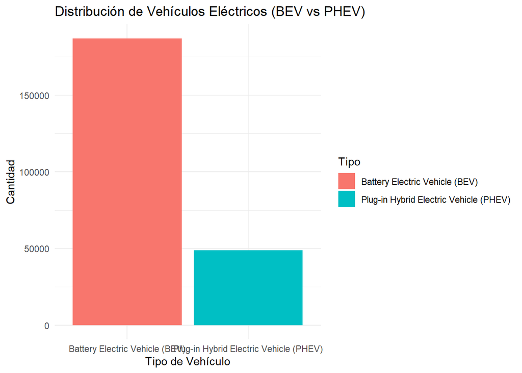

```r
#windows()
ggplot(vehiculos_filtrados, aes(x = Electric.Vehicle.Type, fill = Electric.Vehicle.Type)) +
  geom_bar() +
  labs(title = "Distribución de Vehículos Eléctricos (BEV vs PHEV)",
       x = "Tipo de Vehículo",y = "Cantidad",fill = "Tipo") +  theme_minimal()
```

###Pregunta 3: Diferencias en el alcance eléctrico entre BEV y PHEV

### Gráfico de boxplot comparando BEV y PHEV

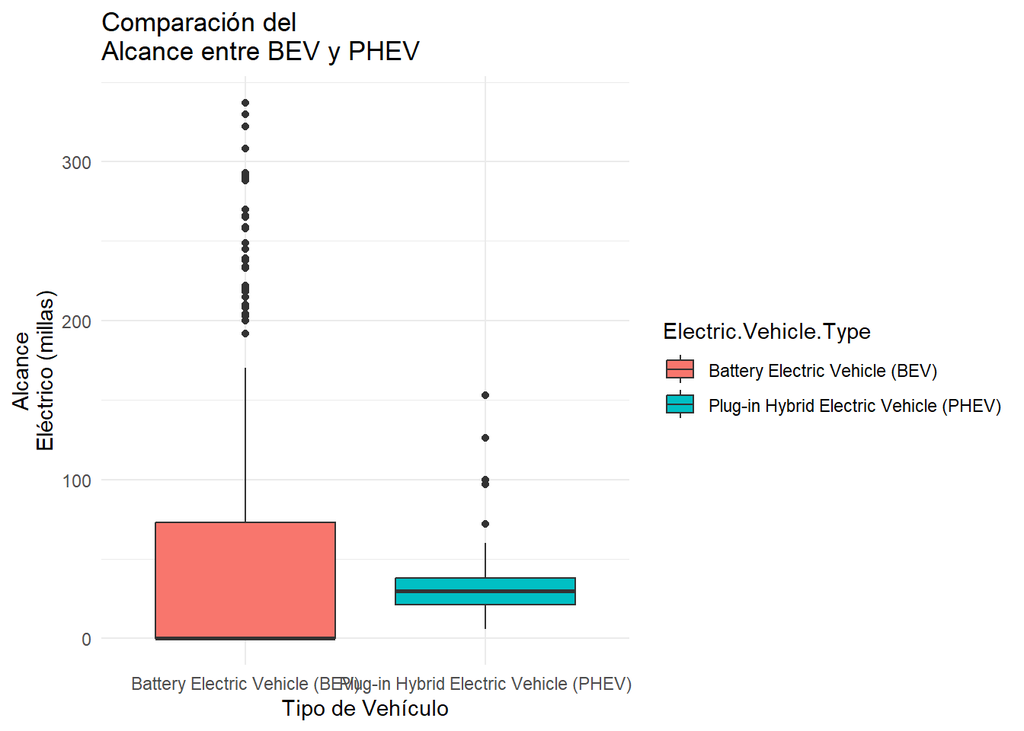

```r
ggplot(datos, aes(x = Electric.Vehicle.Type, y = Electric.Range, fill =
Electric.Vehicle.Type)) + geom_boxplot() + labs(title = "Comparación del
Alcance entre BEV y PHEV", x = "Tipo de Vehículo", y = "Alcance
Eléctrico (millas)") + theme_minimal()
```

###Pregunta 4: Relación entre elegibilidad CAFV y ubicación

### Contar registros por ciudad y elegibilidad

```r
ciudad_elegibilidad <- datos %>%
  group_by(City, Clean.Alternative.Fuel.Vehicle..CAFV..Eligibility) %>%
  summarise(Conteo = n(), .groups = "drop") %>%
  arrange(desc(Conteo))
```

### Obtener la moda (ciudades con mayor frecuencia por tipo de elegibilidad)

```r
moda_ciudades <- ciudad_elegibilidad %>%
  group_by(Clean.Alternative.Fuel.Vehicle..CAFV..Eligibility) %>%
  slice_max(Conteo, n = 5)  # Tomar las 5 ciudades con más registros
# Tomar las 5 ciudades con más registros
```

### Obtener la mediana del conteo de registros por ciudad

```r
mediana_conteo <- median(ciudad_elegibilidad$Conteo)
```

### Obtener la media del conteo de registros por ciudad

```r
media_conteo <- mean(ciudad_elegibilidad$Conteo)
```

### Mostrar resultados

```r
print("Moda (Top ciudades por elegibilidad):")
```

```
## [1] "Moda (Top ciudades por elegibilidad):"
```

```r
print(moda_ciudades)
```

```
## # A tibble: 15 × 3
## # Groups:   Clean.Alternative.Fuel.Vehicle..CAFV..Eligibility [3]
##    City      Clean.Alternative.Fuel.Vehicle..CAFV..Eligibility            Conteo
##    <chr>     <chr>                                                         <int>
##  1 Seattle   Clean Alternative Fuel Vehicle Eligible                       12269
##  2 Bellevue  Clean Alternative Fuel Vehicle Eligible                        3136
##  3 Vancouver Clean Alternative Fuel Vehicle Eligible                        2840
##  4 Redmond   Clean Alternative Fuel Vehicle Eligible                        2180
##  5 Renton    Clean Alternative Fuel Vehicle Eligible                        2078
##  6 Seattle   Eligibility unknown as battery range has not been researched  21596
##  7 Bellevue  Eligibility unknown as battery range has not been researched   7690
##  8 Redmond   Eligibility unknown as battery range has not been researched   5565
##  9 Bothell   Eligibility unknown as battery range has not been researched   5490
## 10 Vancouver Eligibility unknown as battery range has not been researched   4666
## 11 Seattle   Not eligible due to low battery range                          3545
## 12 Vancouver Not eligible due to low battery range                          1004
## 13 Tukwila   Not eligible due to low battery range                           826
## 14 Renton    Not eligible due to low battery range                           709
## 15 Bellevue  Not eligible due to low battery range                           683
```

```r
print(paste("Mediana de registros por ciudad:", mediana_conteo))
```

```
## [1] "Mediana de registros por ciudad: 6"
```

```r
print(paste("Media de registros por ciudad:", round(media_conteo, 2)))
```

```
## [1] "Media de registros por ciudad: 145.13"
```

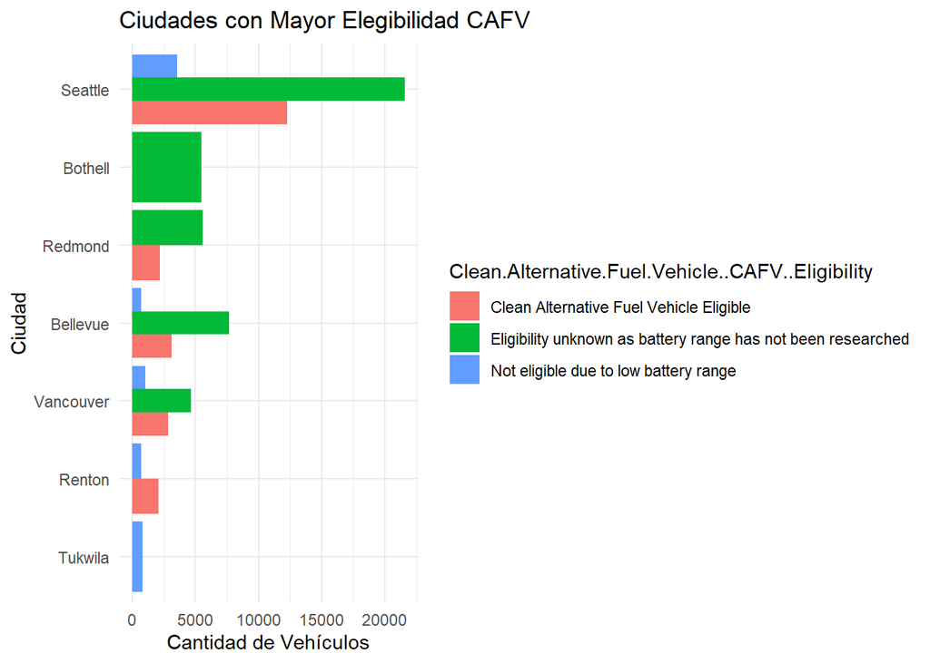

```r
#windows()
ggplot(moda_ciudades, aes(x = reorder(City, Conteo), y =
Conteo, fill = Clean.Alternative.Fuel.Vehicle..CAFV..Eligibility)) +
geom_bar(stat = "identity", position = "dodge") + coord_flip() +
labs(title = "Ciudades con Mayor Elegibilidad CAFV", x = "Ciudad", y =
"Cantidad de Vehículos") + theme_minimal()
```

### Pregunta 5: Relación entre tipo de vehículo y proveedor eléctrico

### Contar registros por Tipo de Vehículo y Proveedor Eléctrico

```r
vehiculo_proveedor <- datos %>%
  group_by(Electric.Vehicle.Type, Electric.Utility) %>%
  summarise(Conteo = n(), .groups = "drop") %>%
  arrange(desc(Conteo))
```

### Obtener la moda (las combinaciones más frecuentes)

```r
moda_vehiculo_proveedor <- vehiculo_proveedor %>%
  group_by(Electric.Vehicle.Type) %>%
  slice_max(Conteo, n = 5)  # Tomar las 5 combinaciones más comunes
```

### Calcular mediana y media del conteo de registros

```r
mediana_conteo <- median(vehiculo_proveedor$Conteo)
media_conteo <- mean(vehiculo_proveedor$Conteo)
```

### Mostrar resultados en consola

```r
print("Moda (Top combinaciones de Tipo de Vehículo y Proveedor Eléctrico):")
```

```
## [1] "Moda (Top combinaciones de Tipo de Vehículo y Proveedor Eléctrico):"
```

```r
print(moda_vehiculo_proveedor)
```

```
## # A tibble: 10 × 3
## # Groups:   Electric.Vehicle.Type [2]
##    Electric.Vehicle.Type                  Electric.Utility                Conteo
##    <chr>                                  <chr>                            <int>
##  1 Battery Electric Vehicle (BEV)         PUGET SOUND ENERGY INC||CITY O…  69806
##  2 Battery Electric Vehicle (BEV)         PUGET SOUND ENERGY INC           39356
##  3 Battery Electric Vehicle (BEV)         CITY OF SEATTLE - (WA)|CITY OF…  32278
##  4 Battery Electric Vehicle (BEV)         BONNEVILLE POWER ADMINISTRATIO…  10361
##  5 Battery Electric Vehicle (BEV)         BONNEVILLE POWER ADMINISTRATIO…   8271
##  6 Plug-in Hybrid Electric Vehicle (PHEV) PUGET SOUND ENERGY INC||CITY O…  15492
##  7 Plug-in Hybrid Electric Vehicle (PHEV) PUGET SOUND ENERGY INC            9567
##  8 Plug-in Hybrid Electric Vehicle (PHEV) CITY OF SEATTLE - (WA)|CITY OF…   7828
##  9 Plug-in Hybrid Electric Vehicle (PHEV) BONNEVILLE POWER ADMINISTRATIO…   3400
## 10 Plug-in Hybrid Electric Vehicle (PHEV) BONNEVILLE POWER ADMINISTRATIO…   2414
```

```r
print(paste("Mediana de registros por combinación:", mediana_conteo))
```

```
## [1] "Mediana de registros por combinación: 108"
```

```r
print(paste("Media de registros por combinación:", round(media_conteo, 2)))
```

```
## [1] "Media de registros por combinación: 1581.83"
```

### 🔹 Visualización de las combinaciones más comunes

[figure not shown]

```r
#windows()
ggplot(moda_vehiculo_proveedor, aes(x = reorder(Electric.Utility, Conteo), y = Conteo, fill = Electric.Vehicle.Type)) +
  geom_bar(stat = "identity", position = "dodge") +
  coord_flip() +
  labs(title = "Relación entre Tipo de Vehículo y Proveedor Eléctrico",
       x = "Proveedor Eléctrico",
       y = "Cantidad de Vehículos") +
  theme_minimal()
```

#### **Conclusiones**

- Los lugares donde los proveedores de electricidad han desarrollado una buena red de carga y existen incentivos claros son los que tienen más vehículos eléctricos. Como nos demuestran las gráficas de la ciudad de Seattle.
- Aunque los híbridos enchufables (PHEV) se encuentren en el mercado, la mayoría de las personas están optando por los vehículos 100% eléctricos (BEV). Esto indica que la tecnología ha avanzado permitiendo mayor autonomía en estos, que los incentivos y lugares de carga cada vez están mejor distribuidos.
- Las empresas de electricidad tienen un rol clave en el futuro de la movilidad. No es solo una cuestión de que las personas quieran cambiar a autos eléctricos, sino que las compañías eléctricas deben estar preparadas para abastecer esa demanda. Aquellas que ya han trabajado en infraestructura están viendo cómo en sus regiones el número de autos eléctricos crece más rápido.
- Las compañías eléctricas deben estar preparadas para abastecer la demanda con su infraestructura ya que están viendo cómo en sus regiones el número de autos eléctricos crece más rápido.
- Aunque hay avances importantes, aún hay proveedores con muy pocos autos eléctricos en sus redes, lo que indica que en algunas zonas falta infraestructura o incentivos atractivos.

#### **Referencias**

- Data.gov. (n.d.). Electric Vehicle Population Data. Retrieved fromhttps://catalog.data.gov/dataset/electric-vehicle-population-data